# MMDraftDataScript

Heather Leonard, Abbie Sanders, and Rebecca Gordon

11/18/2021

I’d add a space between these code chunks for visual clarity :)

```r
#installing gtsummary to help with creating summary tables
#install.packages("gtsummary")
```

```r
library(rio)
library(tidyverse)
library(here)
library(janitor)
library(gtsummary)
```

```r
synthdata <- read.csv(here ("data", "synthdata.csv")) %>%
  as_tibble()
```

Notes for working on final project: Final project must use the following functions: pivot_longer(), select(), filter(), mutate(), pivot_wider(), group_by(), and summarize().

Research question: Is internet overuse associated with sleep outcomes (total sleep, daytime sleepiness) in adolescents?

Possible covariates: dm_childage_bl, dm_sex_bl, dm_lunch_bl

1. select() and filter() will be used for narrowing down data to the variables we want
2. recode io variables will use mutate()
3. record age variable will use mutate()
4. create the composite score for io variables
5. in ggplot we can use group_by()
6. summarize() by making a descriptives/summary table, possibly use pivots

```r
#recode internet overuse score and create a composite score
synthdata <- synthdata %>%
  mutate(io1_RC = recode(io1_bl, "i don't know" = 0, "never" = 1, "often" = 2, "rarely" = 3, "sometimes" = 4))%>%
  mutate(io2_RC = recode(io2_bl, "i don't know" = 0, "never" = 1, "often" = 2, "rarely" = 3, "sometimes" = 4)) %>%
  mutate(io3_RC = recode(io3_bl, "i don't know" = 0, "never" = 1, "often" = 2, "rarely" = 3, "sometimes" = 4)) %>%
  mutate(io4_RC = recode(io4_bl, "i don't know" = 0, "never" = 1, "often" = 2, "rarely" = 3, "sometimes" = 4)) %>%
  mutate(io_comp = io1_RC + io2_RC + io3_RC + io4_RC)

#recode age
synthdata$age_RC <- as.numeric(str_sub(synthdata$dm_childage_bl, 1,2))
```

wow nicely done! This r abbie chunk looks beautiful!

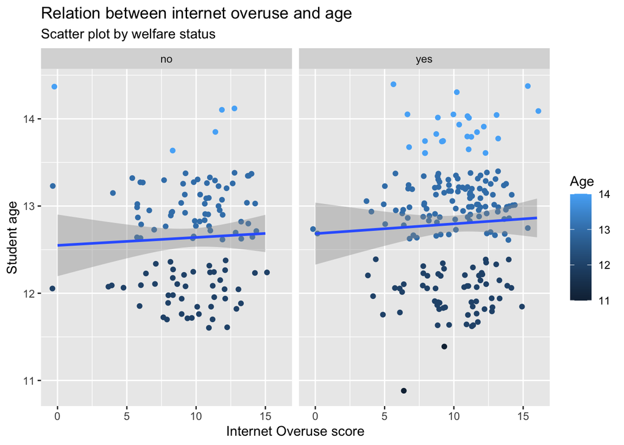

```r
#Removes all "i don't know" values
synthdata <- synthdata %>%
filter(synthdata$age_RC != "i don't know" & synthdata$dm_lunch_bl != "i don't know")

synthdata %>%
  ggplot(aes(io_comp, age_RC)) +
  geom_jitter(aes(color = age_RC)) +
  geom_smooth(method = "lm") +
  facet_wrap(~dm_lunch_bl) +
  labs(title = 'Relation between internet overuse and age', subtitle = 'Scatter plot by welfare status', x = 'Internet Overuse score', y = 'Student age', color = 'Age')
```

For the title, I would consider changing relation to relationship, and capitalizing the other applicable words! Is the “no” and “yes” referring to receiving or not receiving welfare? It might be a bit clearer if it said “receives”, “Does not receive” BUT that is totally personal preference, and I wouldn’t even know how to do that! The graph is BEAUTIFUL and I could look at it forever. NICELY DONE!!!!

```r
synthdata %>%
  select(1:6, io1_RC:io4_RC)  %>%
  pivot_longer(
    cols = starts_with("io"),
    names_to = "variables",
    values_to = "answers"
  )
```

```
## # A tibble: 1,240 × 8
##    grade dm_childage_bl dm_sex_bl dm_ethnic_bl  dm_race_bl dm_lunch_bl variables
##    <int> <chr>          <chr>     <chr>         <chr>      <chr>       <chr>
##  1     7 12 years       male      non-hispanic… white or … no          io1_RC
##  2     7 12 years       male      non-hispanic… white or … no          io2_RC
##  3     7 12 years       male      non-hispanic… white or … no          io3_RC
##  4     7 12 years       male      non-hispanic… white or … no          io4_RC
##  5     7 12 years       female    non-hispanic… white or … yes         io1_RC
##  6     7 12 years       female    non-hispanic… white or … yes         io2_RC
##  7     7 12 years       female    non-hispanic… white or … yes         io3_RC
##  8     7 12 years       female    non-hispanic… white or … yes         io4_RC
##  9     7 12 years       male      hispanic or … more than… yes         io1_RC
## 10     7 12 years       male      hispanic or … more than… yes         io2_RC
## # … with 1,230 more rows, and 1 more variable: answers <dbl>
```

The pivoting is beautiful!! I might add the prefix “dm_” to get rid of the “dm_” before the category names in the columns.

```r
#just playing around with pivotlonger here to see if we could come up with anything. it didn't work well. Need to come up with something.
synthdata %>%
  pivot_longer(cols = grade, names_to = "variables", values_to = "answers")
```

```
## # A tibble: 310 × 24
##    dm_childage_bl dm_sex_bl dm_ethnic_bl  dm_race_bl   dm_lunch_bl io1_bl io2_bl
##    <chr>          <chr>     <chr>         <chr>        <chr>       <chr>  <chr>
##  1 12 years       male      non-hispanic… white or eu… no          rarely rarely
##  2 12 years       female    non-hispanic… white or eu… yes         somet… rarely
##  3 12 years       male      hispanic or … more than o… yes         often  rarely
##  4 12 years       male      non-hispanic… white or eu… yes         somet… somet…
##  5 13 years       male      non-hispanic… white or eu… no          somet… never
##  6 13 years       female    unknown/refu… unknown      yes         often  rarely
##  7 13 years       male      non-hispanic… more than o… no          somet… rarely
##  8 12 years       female    non-hispanic… white or eu… yes         never  rarely
##  9 14 years       male      non-hispanic… more than o… yes         somet… never
## 10 14 years       male      non-hispanic… more than o… yes         somet… never
## # … with 300 more rows, and 17 more variables: io3_bl <chr>, io4_bl <chr>,
## #   sl_sleepschool_bl <dbl>, sl_sleepweekend_bl <dbl>, sl_sleepy_bl <int>,
## #   sl_avgsleepcat_bl <chr>, sl_avgsleepwncat_bl <chr>, sl_latcat_bl <chr>,
## #   sl_bedmedia_bl <dbl>, io1_RC <dbl>, io2_RC <dbl>, io3_RC <dbl>,
## #   io4_RC <dbl>, io_comp <dbl>, age_RC <dbl>, variables <chr>, answers <int>
```

I saw your comment about still working on this one above but it’s a great start!!!

```r
synthdata %>%
  group_by(dm_sex_bl) %>%
  summarise(mean_io = mean(io_comp))
```

```
## # A tibble: 3 × 2
##   dm_sex_bl mean_io
##   <chr>       <dbl>
## 1 female       9.72
## 2 male        10.1
## 3 other        9
```

Oh that’s super interesting! It would be really cool to see the mean broken down by race/ethnicity as well!

```r
synthdata %>%
  group_by(dm_sex_bl) %>%
  summarise(mean_io = mean(io_comp)) %>%
  pivot_wider(names_from = dm_sex_bl, values_from = mean_io)
```

```
## # A tibble: 1 × 3
##   female  male other
##    <dbl> <dbl> <dbl>
## 1   9.72  10.1     9
```

Nicely done!!!

```r
#this makes a giant table of all variables
synthdata %>%
  tbl_summary()
```

| **Characteristic** | **N = 310**<sup>1</sup> |
| --- | --- |
| grade |  |
| 7 | 143 (46%) |
| 8 | 167 (54%) |
| dm_childage_bl |  |
| 11 years | 2 (0.6%) |
| 12 years | 108 (35%) |
| 13 years | 169 (55%) |
| 14 years | 31 (10%) |
| dm_sex_bl |  |
| female | 150 (48%) |
| male | 159 (51%) |
| other | 1 (0.3%) |
| dm_ethnic_bl |  |
| hispanic or latino | 90 (29%) |
| non-hispanic or latino | 145 (47%) |
| unknown/refused | 75 (24%) |
| dm_race_bl |  |
| american indian/alaska native | 18 (5.8%) |
| black or african american | 11 (3.5%) |
| more than one race | 114 (37%) |
| unknown | 56 (18%) |
| white or european american | 111 (36%) |
| dm_lunch_bl | 197 (64%) |
| io1_bl |  |
| i don't know | 8 (2.6%) |
| never | 17 (5.5%) |
| often | 73 (24%) |
| rarely | 68 (22%) |
| sometimes | 144 (46%) |
| io2_bl |  |

[output cut: 73 more lines]

<sup>*1*</sup> n (%); Median (IQR)

That is an awesome table! I really like being able to see the percentages like that! It also makes the data readable to non-experts and non-r users :)

```r
#this will split out the characteristics by sex and add p value with second line. filtered out one gender answer of "other."
synthdata %>%
  filter(dm_sex_bl != "other") %>%
  tbl_summary(by = dm_sex_bl) %>%
  add_p()
```

| **Characteristic** | **female**, N = 150<sup>1</sup> | **male**, N = 159<sup>1</sup> | **p-value**<sup>2</sup> |
| --- | --- | --- | --- |
| grade |  |  | >0.9 |
| 7 | 69 (46%) | 73 (46%) |  |
| 8 | 81 (54%) | 86 (54%) |  |
| dm_childage_bl |  |  | 0.7 |
| 11 years | 0 (0%) | 2 (1.3%) |  |
| 12 years | 54 (36%) | 53 (33%) |  |
| 13 years | 80 (53%) | 89 (56%) |  |
| 14 years | 16 (11%) | 15 (9.4%) |  |
| dm_ethnic_bl |  |  | 0.4 |
| hispanic or latino | 42 (28%) | 48 (30%) |  |
| non-hispanic or latino | 76 (51%) | 69 (43%) |  |
| unknown/refused | 32 (21%) | 42 (26%) |  |
| dm_race_bl |  |  | 0.3 |
| american indian/alaska native | 7 (4.7%) | 11 (6.9%) |  |
| black or african american | 5 (3.3%) | 6 (3.8%) |  |
| more than one race | 48 (32%) | 65 (41%) |  |
| unknown | 27 (18%) | 29 (18%) |  |
| white or european american | 63 (42%) | 48 (30%) |  |
| dm_lunch_bl | 91 (61%) | 106 (67%) | 0.3 |
| io1_bl |  |  | 0.2 |
| i don't know | 2 (1.3%) | 6 (3.8%) |  |
| never | 9 (6.0%) | 8 (5.0%) |  |
| often | 41 (27%) | 32 (20%) |  |
| rarely | 27 (18%) | 41 (26%) |  |
| sometimes | 71 (47%) | 72 (45%) |  |
| io2_bl |  |  | 0.7 |
| i don't know | 3 (2.0%) | 5 (3.1%) |  |
| never | 41 (27%) | 46 (29%) |  |
| often | 18 (12%) | 14 (8.8%) |  |
| rarely | 49 (33%) | 59 (37%) |  |

[output cut: 69 more lines]

<sup>*1*</sup> n (%); Median (IQR) <sup>*2*</sup> Pearson's Chi-squared test; Fisher's exact test; Wilcoxon rank sum test

This was easy to read and fun to see p values! Nice work!!

```r
synthdata %>%
  select(sl_avgsleepcat_bl, io_comp) %>%
  tbl_summary(by = sl_avgsleepcat_bl) %>%
  add_p()
```

```
## 7 observations missing `sl_avgsleepcat_bl` have been removed. To include these observations, use `forcats::fct_explicit_na()` on `sl_avgsleepcat_bl` column before passing to `tbl_summary()`.
```

| **Characteristic** | **6 hrs or less**, N = 8<sup>1</sup> | **6-8 hrs**, N = 58<sup>1</sup> | **8-10 hrs**, N = 211<sup>1</sup> | **More than 10 hrs**, N = 26<sup>1</sup> | **p-value**<sup>2</sup> |
| --- | --- | --- | --- | --- | --- |
| io_comp | 10.00 (8.75, 11.00) | 10.00 (8.00, 12.00) | 11.00 (9.00, 12.00) | 8.00 (6.25, 12.00) | 0.3 |

<sup>*1*</sup> Median (IQR) <sup>*2*</sup> Kruskal-Wallis rank sum test

```r
synthdata %>%
  select(sl_bedmedia_bl, io_comp) %>%
  tbl_summary(by = sl_bedmedia_bl) %>%
  add_p()
```

```
## 19 observations missing `sl_bedmedia_bl` have been removed. To include these observations, use `forcats::fct_explicit_na()` on `sl_bedmedia_bl` column before passing to `tbl_summary()`.
```

| **Characteristic** | **0**, N = 9<sup>1</sup> | **0.285714285714286**, N = 3<sup>1</sup> | **0.571428571428571**, N = 1<sup>1</sup> | **0.714285714285714**, N = 5<sup>1</sup> | **0.857142857142857**, N = 4<sup>1</sup> | **1**, N = 17<sup>1</sup> | **1.28571428571429**, N = 12<sup>1</sup> | **1.57142857142857**, N = 7<sup>1</sup> | **1.71428571428571**, N = 3<sup>1</sup> | **2**, N = 23<sup>1</sup> | **2.28571428571429**, N = 39<sup>1</sup> | **2.42857142857143**, N = 2<sup>1</sup> | **2.71428571428571**, N = 9<sup>1</sup> | **3**, N = 157<sup>1</sup> | **p-value**<sup>2</sup> |
| --- | --- | --- | --- | --- | --- | --- | --- | --- | --- | --- | --- | --- | --- | --- | --- |
| io_comp | 6.00 (4.00, 7.00) | 9.00 (4.50, 9.50) | 5.00 (5.00, 5.00) | 7.00 (6.00, 11.00) | 6.50 (5.75, 8.50) | 10.00 (9.00, 12.00) | 10.00 (8.75, 13.00) | 9.00 (5.00, 11.00) | 13.00 (11.50, 13.00) | 12.00 (9.00, 12.50) | 10.00 (8.00, 12.00) | 12.00 (11.50, 12.50) | 11.00 (10.00, 13.00) | 11.00 (9.00, 12.00) | 0.008 |

<sup>*1*</sup> Median (IQR) <sup>*2*</sup> Kruskal-Wallis rank sum test

I would split this code chunk like I just did with this comment. Especially because you are answering your research question, I think it’ll be clearer and also look nice to have a header here and for it to have it’s own section :)

```r
#answer to our research question: positive relationship that is very very small
cor(synthdata$sl_bedmedia_bl, synthdata$io_comp, method = "pearson", use = "complete.obs")
```

```
## [1] 0.2187816
```

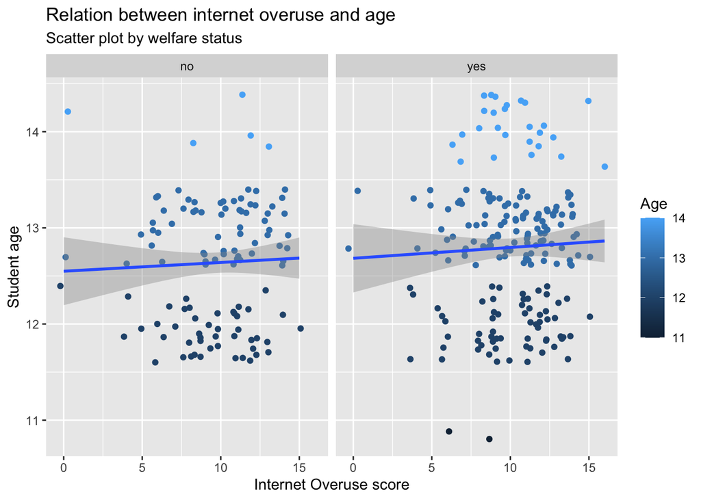

```r
#Removes all "i don't know" values
synthdata <- synthdata %>%
filter(synthdata$age_RC != "i don't know" & synthdata$dm_lunch_bl != "i don't know")

synthdata %>%
  ggplot(aes(io_comp, age_RC)) +
  geom_jitter(aes(color = age_RC)) +
  geom_smooth(method = "lm") +
  facet_wrap(~dm_lunch_bl) +
  labs(title = 'Relation between internet overuse and age', subtitle = 'Scatter plot by welfare status', x = 'Internet Overuse score', y = 'Student age', color = 'Age')
```

I added the ticks at the end of this last chunk so that it would run! Looks like the same graph as earlier. Again, it is beautiful. Nicely done you guys!! Please let me know if there’s anything I can do to help! I doubt you’ll need anything though :)